# Bag of Words Meets Bags of Popcorn

#### Importing libraries

```python
#Librarises
import pandas as pd  #data processing and data level operation
import numpy as np  # Linear Algebra
import os, re
import string
import nltk
from nltk.corpus import stopwords

#Visualization libraries
import matplotlib.pyplot as plt
import seaborn as sns
from wordcloud import WordCloud,STOPWORDS

%matplotlib inline
###For downlaod the nltk
########nltk.download()
```

```python
#Current working directory
print('current workind directory ==== ',os.getcwd())

#Loading data
train = pd.read_csv('Input/labeledTrainData.tsv',delimiter = '\t')
test = pd.read_csv('Input/testData.tsv',delimiter = '\t')

train.shape, test.shape
```

```
current workind directory ====  C:\Users\parve\Documents\Bag_of_Words_Meets_Bags_of_Popcorn_Kaggle
```

```
((25000, 3), (25000, 2))
```

```python
train.head()
```

|  | id | sentiment | review |
| --- | --- | --- | --- |
| 0 | 5814_8 | 1 | With all this stuff going down at the moment w... |
| 1 | 2381_9 | 1 | \The Classic War of the Worlds\" by Timothy Hi... |
| 2 | 7759_3 | 0 | The film starts with a manager (Nicholas Bell)... |
| 3 | 3630_4 | 0 | It must be assumed that those who praised this... |
| 4 | 9495_8 | 1 | Superbly trashy and wondrously unpretentious 8... |

```python
train['review'][0]
```

```
"With all this stuff going down at the moment with MJ i've started listening to his music, watching the odd documentary here and there, watched The Wiz and watched Moonwalker again. Maybe i just want to get a certain insight into this guy who i thought was really cool in the eighties just to maybe m…
```

```python
test.head()
```

|  | id | review |
| --- | --- | --- |
| 0 | 12311_10 | Naturally in a film who's main themes are of m... |
| 1 | 8348_2 | This movie is a disaster within a disaster fil... |
| 2 | 5828_4 | All in all, this is a movie for kids. We saw i... |
| 3 | 7186_2 | Afraid of the Dark left me with the impression... |
| 4 | 12128_7 | A very accurate depiction of small time mob li... |

```python
test['review'][0]
```

```
"Naturally in a film who's main themes are of mortality, nostalgia, and loss of innocence it is perhaps not surprising that it is rated more highly by older viewers than younger ones. However there is a craftsmanship and completeness to the film which anyone can enjoy. The pace is steady and constan…
```

```python
print ("number of rows for sentiment 1: {}".format(len(train[train.sentiment == 1])))
print ( "number of rows for sentiment 0: {}".format(len(train[train.sentiment == 0])))
```

```
number of rows for sentiment 1: 12500
number of rows for sentiment 0: 12500
```

There is equal distribution of data

```python
train.groupby('sentiment').describe().transpose()
```

|  | sentiment | 0 | 1 |
| --- | --- | --- | --- |
| id | count | 12500 | 12500 |
|  | unique | 12500 | 12500 |
|  | top | 1582_1 | 5081_8 |
|  | freq | 1 | 1 |
| review | count | 12500 | 12500 |
|  | unique | 12432 | 12472 |
|  | top | This show comes up with interesting locations ... | THE JIST: See something else.<br /><br />This ... |
|  | freq | 3 | 2 |

```python
#Creating a new col
train['length'] = train['review'].apply(len)
train.head()
```

|  | id | sentiment | review | length |
| --- | --- | --- | --- | --- |
| 0 | 5814_8 | 1 | With all this stuff going down at the moment w... | 2302 |
| 1 | 2381_9 | 1 | \The Classic War of the Worlds\" by Timothy Hi... | 946 |
| 2 | 7759_3 | 0 | The film starts with a manager (Nicholas Bell)... | 2449 |
| 3 | 3630_4 | 0 | It must be assumed that those who praised this... | 2245 |
| 4 | 9495_8 | 1 | Superbly trashy and wondrously unpretentious 8... | 2231 |

### Data Visualization

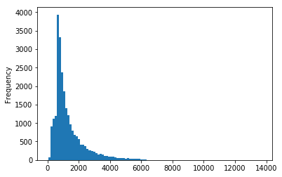

```python
#Histogram of count of letters
train['length'].plot.hist(bins = 100)
```

```python
train.length.describe()
```

```
count    25000.000000
mean      1327.710560
std       1005.239246
min         52.000000
25%        703.000000
50%        981.000000
75%       1617.000000
max      13708.000000
Name: length, dtype: float64
```

```python
#train[train['length'] == 13708]['review']
train[train['length'] == 13708]['review'].iloc[0]
```

```
'Match 1: Tag Team Table Match Bubba Ray and Spike Dudley vs Eddie Guerrero and Chris Benoit Bubba Ray and Spike Dudley started things off with a Tag Team Table Match against Eddie Guerrero and Chris Benoit. According to the rules of the match, both opponents have to go through tables in order to ge…
```

[output not shown]

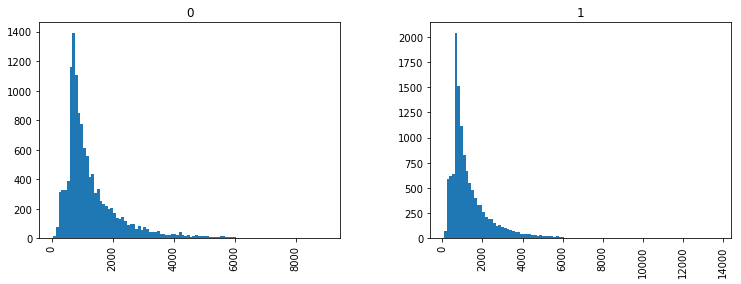

```python
train.hist(column='length', by='sentiment', bins=100,figsize=(12,4))
```

### Text Preprocessing

```python
from bs4 import BeautifulSoup

#Creating a function for cleaning of data
def clean_text(raw_text):
    # 1. remove HTML tags
    raw_text = BeautifulSoup(raw_text).get_text()

    # 2. removing all non letters from text
    letters_only = re.sub("[^a-zA-Z]", " ", raw_text)

    # 3. Convert to lower case, split into individual words
    words = letters_only.lower().split()

    # 4. Create variable which contain set of stopwords
    stops = set(stopwords.words("english"))

    # 5. Remove stop word & returning
    return [w for w in words if not w in stops]
```

```python
#Cleaning review and also adding a new col as its len count of words
train['clean_review'] = train['review'].apply(clean_text)
train['length_clean_review'] = train['clean_review'].apply(len)
train.head()
```

|  | id | sentiment | review | length | clean_review | length_clean_review |
| --- | --- | --- | --- | --- | --- | --- |
| 0 | 5814_8 | 1 | With all this stuff going down at the moment w... | 2302 | [stuff, going, moment, mj, started, listening,... | 219 |
| 1 | 2381_9 | 1 | \The Classic War of the Worlds\" by Timothy Hi... | 946 | [classic, war, worlds, timothy, hines, enterta... | 84 |
| 2 | 7759_3 | 0 | The film starts with a manager (Nicholas Bell)... | 2449 | [film, starts, manager, nicholas, bell, giving... | 240 |
| 3 | 3630_4 | 0 | It must be assumed that those who praised this... | 2245 | [must, assumed, praised, film, greatest, filme... | 189 |
| 4 | 9495_8 | 1 | Superbly trashy and wondrously unpretentious 8... | 2231 | [superbly, trashy, wondrously, unpretentious, ... | 210 |

```python
train.describe()
```

|  | sentiment | length | length_clean_review |
| --- | --- | --- | --- |
| count | 25000.00000 | 25000.000000 | 25000.000000 |
| mean | 0.50000 | 1327.710560 | 119.523560 |
| std | 0.50001 | 1005.239246 | 90.583576 |
| min | 0.00000 | 52.000000 | 4.000000 |
| 25% | 0.00000 | 703.000000 | 63.000000 |
| 50% | 0.50000 | 981.000000 | 89.000000 |
| 75% | 1.00000 | 1617.000000 | 146.000000 |
| max | 1.00000 | 13708.000000 | 1416.000000 |

```python
#Checking the smallest review
print(train[train['length_clean_review'] == 4]['review'].iloc[0])
print('------After Cleaning------')
print(train[train['length_clean_review'] == 4]['clean_review'].iloc[0])
```

```
This movie is terrible but it has some good effects.
------After Cleaning------
['movie', 'terrible', 'good', 'effects']
```

### Word CLoud

Wordcloud before cleaning

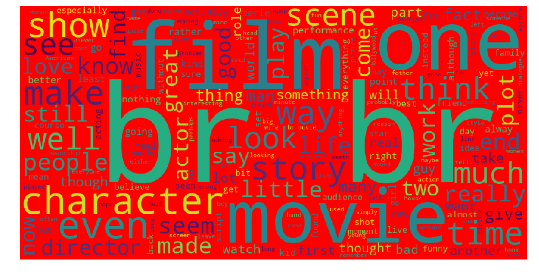

```python
#Plot wordcloud
word_cloud = WordCloud(width = 1000, height = 500, stopwords = STOPWORDS, background_color = 'red').generate(
                        ''.join(train['review']))

plt.figure(figsize = (15,8))
plt.imshow(word_cloud)
plt.axis('off')
plt.show()

#word_cloud.to_file('aa.png')   #for saving file
```

### Vectorization

Now we'll convert each review, represented as a list of tokens into a vector that machine learning models can understand.

We'll do that in three steps using the bag-of-words model:

1. Count how many times does a word occur in each message (Known as term frequency)
2. Weigh the counts, so that frequent tokens get lower weight (inverse document frequency)
3. Normalize the vectors to unit length, to abstract from the original text length (L2 norm)

Let's begin the first step:

```python
from sklearn.feature_extraction.text import CountVectorizer
```

There are a lot of arguments and parameters that can be passed to the CountVectorizer. In this case we will just specify the **analyzer** to be our own previously defined function:

```python
# Might take awhile...
bow_transform = CountVectorizer(analyzer=clean_text).fit(train['review'])  #bow = bag of word

# Print total number of vocab words
print(len(bow_transform.vocabulary_))
```

```
74065
```

Let's take one text message and get its bag-of-words counts as a vector, putting to use our new **bow_transformer**

```python
review1 = train['review'][1]
print(review1)
```

```
\The Classic War of the Worlds\" by Timothy Hines is a very entertaining film that obviously goes to great effort and lengths to faithfully recreate H. G. Wells' classic book. Mr. Hines succeeds in doing so. I, and those who watched his film with me, appreciated the fact that it was not the standard…
```

Now let's see its vector representation:

```python
bow1 = bow_transform.transform([review1])
print(bow1)
print(bow1.shape)
```

```
  (0, 1153)	1
  (0, 1860)	1
  (0, 2877)	1
  (0, 5089)	1
  (0, 7345)	2
  (0, 11671)	3
  (0, 12493)	1
  (0, 14613)	1
  (0, 14617)	3
  (0, 14782)	1
  (0, 17310)	1
  (0, 19658)	1
  (0, 19759)	1
  (0, 20008)	2
  (0, 20901)	1
  (0, 21030)	1
  (0, 21035)	2
  (0, 21147)	1
  (0, 21748)	1
  (0, 21754)	1
  (0, 21757)	1
  (0, 22499)	1
  (0, 22584)	1
  (0, 22585)	1
  (0, 22788)	1
  :	:
  (0, 45216)	1
  (0, 45629)	2
  (0, 46521)	1
  (0, 46850)	1
  (0, 48251)	1
  (0, 48288)	1
  (0, 50446)	1
  (0, 51816)	1
  (0, 52690)	1
  (0, 53240)	1
  (0, 54251)	1
  (0, 58936)	1
  (0, 59991)	1
  (0, 61334)	1
  (0, 61943)	1
  (0, 63259)	1
  (0, 65725)	1
  (0, 66191)	1
  (0, 66463)	1
  (0, 70380)	1
  (0, 71340)	1
  (0, 71498)	1
  (0, 71821)	2
  (0, 72911)	1
  (0, 73396)	1
(1, 74065)
```

Here 2 and 1 represent the occurance of word in the text phase & Number like '73396' are index of that particular word

```python
print(bow_transform.get_feature_names()[71821])
print(bow_transform.get_feature_names()[72911])
```

```
wells
worlds
```

Above both words stores on that particular index

```python
#Creating bag of words for our review variable
review_bow = bow_transform.transform(train['review'])
```

Checking the shape and non zero occurances of our sparse matrix that we have just generated

```python
print('Shape of Sparse Matrix: ', review_bow.shape)
print('Amount of Non-Zero occurences: ', review_bow.nnz)
```

```
Shape of Sparse Matrix:  (25000, 74065)
Amount of Non-Zero occurences:  2450404
```

Checking the sparsity of sparse matrix

```python
sparsity = (100.0 * review_bow.nnz / (review_bow.shape[0] * review_bow.shape[1]))
print('sparsity: {}'.format(sparsity))
```

```
sparsity: 0.1323380274083575
```

### TF-IDF

Term Frequency - Inverse Document Frequency.

After the counting, the term weighting and normalization can be done with tf-idf

**TF: Term Frequency**, which measures how frequently a term occurs in a document. Since every document is different in length, it is possible that a term would appear much more times in long documents than shorter ones. Thus, the term frequency is often divided by the document length (aka. the total number of terms in the document) as a way of normalization:

*TF(t) = (Number of times term t appears in a document) / (Total number of terms in the document).*

**IDF: Inverse Document Frequency**, which measures how important a term is. While computing TF, all terms are considered equally important. However it is known that certain terms, such as "is", "of", and "that", may appear a lot of times but have little importance. Thus we need to weigh down the frequent terms while scale up the rare ones, by computing the following:

*IDF(t) = log_e(Total number of documents / Number of documents with term t in it).*

```python
from sklearn.feature_extraction.text import TfidfTransformer

tfidf_transformer = TfidfTransformer().fit(review_bow)
tfidf1 = tfidf_transformer.transform(bow1)
print(tfidf1)
```

```
  (0, 73396)	0.061582405387422844
  (0, 72911)	0.10916204090045824
  (0, 71821)	0.24678226776886478
  (0, 71498)	0.06130848347869254
  (0, 71340)	0.07054912976037264
  (0, 70380)	0.06691025207731116
  (0, 66463)	0.08376908496574231
  (0, 66191)	0.11391853286104583
  (0, 65725)	0.05408056138661737
  (0, 63259)	0.1047755178999042
  (0, 61943)	0.08811567227327795
  (0, 61334)	0.11302952635114163
  (0, 59991)	0.10986956065151147
  (0, 58936)	0.11997053429431336
  (0, 54251)	0.11268631063864525
  (0, 53240)	0.13073660913364496
  (0, 52690)	0.0824732205199774
  (0, 51816)	0.05986262652464556
  (0, 50446)	0.077539268028452
  (0, 48288)	0.13122486190259133
  (0, 48251)	0.04143735557967593
  (0, 46850)	0.11689701180182505
  (0, 46521)	0.06665775481300043
  (0, 45629)	0.14376840111740952
  (0, 45216)	0.08006252757098449
  :	:
  (0, 22788)	0.10110289576849556
  (0, 22585)	0.13850169616266522
  (0, 22584)	0.10403788202119751
  (0, 22499)	0.05424308473387671
  (0, 21757)	0.06083289839379746
  (0, 21754)	0.061698576872810384
  (0, 21748)	0.05242341055581426
  (0, 21147)	0.15476362331540858
  (0, 21035)	0.13604634273405658
  (0, 21030)	0.09882124404859957
  (0, 20901)	0.07083536374522043
  (0, 20008)	0.157199580701254
  (0, 19759)	0.07836365826349871
  (0, 19658)	0.07985680613966428
  (0, 17310)	0.06153793056932126
  (0, 14782)	0.11285706893716993
  (0, 14617)	0.27545778646953534
  (0, 14613)	0.12469981772952707
  (0, 12493)	0.059734063471707025
  (0, 11671)	0.19644327376607876
  (0, 7345)	0.1337237458106877
  (0, 5089)	0.1363767739136488
  (0, 2877)	0.10199648681145218
  (0, 1860)	0.1015439329781005
  (0, 1153)	0.0836096374096924
```

We'll go ahead and check what is the IDF (inverse document frequency) of the word `"war"` and of word `"book"`?

```python
print(tfidf_transformer.idf_[bow_transform.vocabulary_['war']])
print(tfidf_transformer.idf_[bow_transform.vocabulary_['book']])
```

```
4.070495818949949
3.8577509748566374
```

To transform the entire bag-of-words corpus into TF-IDF corpus at once:

```python
review_tfidf = tfidf_transformer.transform(review_bow)
print(review_tfidf.shape)
```

```
(25000, 74065)
```

## Modeling Part

#### Train Test Split

```python
from sklearn.model_selection import train_test_split

X_train, X_test, y_train, y_test = train_test_split(train['review'], train['sentiment'], test_size=0.22, random_state=101)

len(X_train), len(X_test), len(X_train) + len(X_test)
```

```
(19500, 5500, 25000)
```

#### Result Function

```python
from sklearn.metrics import classification_report
#Predicting & Stats Function
def pred(predicted,compare):
    cm = pd.crosstab(compare,predicted)
    TN = cm.iloc[0,0]
    FN = cm.iloc[1,0]
    TP = cm.iloc[1,1]
    FP = cm.iloc[0,1]
    print("CONFUSION MATRIX ------->> ")
    print(cm)
    print()

    ##check accuracy of model
    print('Classification paradox :------->>')
    print('Accuracy :- ', round(((TP+TN)*100)/(TP+TN+FP+FN),2))
    print()
    print('False Negative Rate :- ',round((FN*100)/(FN+TP),2))
    print()
    print('False Postive Rate :- ',round((FP*100)/(FP+TN),2))
    print()
    print(classification_report(compare,predicted))
```

### Training Model

#### Logistic Regression

```python
from sklearn.linear_model import LogisticRegression
from sklearn.pipeline import Pipeline

pipeline = Pipeline([
    ('bow', CountVectorizer(analyzer=clean_text)),  # strings to token integer counts
    ('tfidf', TfidfTransformer()),  # integer counts to weighted TF-IDF scores
    ('classifier', LogisticRegression(random_state=101)),  # train on TF-IDF vectors w/ Naive Bayes classifier
])

pipeline.fit(X_train,y_train)
predictions = pipeline.predict(X_train)
pred(predictions,y_train)
```

```
CONFUSION MATRIX ------->>
col_0         0     1
sentiment
0          9042   682
1           499  9277

Classification paradox :------->>
Accuracy :-  93.94

False Negative Rate :-  5.1

False Postive Rate :-  7.01

             precision    recall  f1-score   support

          0       0.95      0.93      0.94      9724
          1       0.93      0.95      0.94      9776

avg / total       0.94      0.94      0.94     19500
```

```python
#Test Set Result
predictions = pipeline.predict(X_test)
pred(predictions,y_test)
```

```
CONFUSION MATRIX ------->>
col_0         0     1
sentiment
0          2424   352
1           267  2457

Classification paradox :------->>
Accuracy :-  88.75

False Negative Rate :-  9.8

False Postive Rate :-  12.68

             precision    recall  f1-score   support

          0       0.90      0.87      0.89      2776
          1       0.87      0.90      0.89      2724

avg / total       0.89      0.89      0.89      5500
```

##### Naive Bayes Model

```python
from sklearn.pipeline import Pipeline
from sklearn.naive_bayes import MultinomialNB

pipeline = Pipeline([
    ('bow', CountVectorizer(analyzer=clean_text)),  # strings to token integer counts
    ('tfidf', TfidfTransformer()),  # integer counts to weighted TF-IDF scores
    ('classifier', MultinomialNB()),  # train on TF-IDF vectors w/ Naive Bayes classifier
])

pipeline.fit(X_train,y_train)
predictions = pipeline.predict(X_train)
pred(predictions,y_train)
```

```
CONFUSION MATRIX ------->>
col_0         0     1
sentiment
0          9054   670
1           843  8933

Classification paradox :------->>
Accuracy :-  92.24

False Negative Rate :-  8.62

False Postive Rate :-  6.89

             precision    recall  f1-score   support

          0       0.91      0.93      0.92      9724
          1       0.93      0.91      0.92      9776

avg / total       0.92      0.92      0.92     19500
```

```python
#Result on Test Case
predictions = pipeline.predict(X_test)
pred(predictions,y_test)
```

```
CONFUSION MATRIX ------->>
col_0         0     1
sentiment
0          2423   353
1           352  2372

Classification paradox :------->>
Accuracy :-  87.18

False Negative Rate :-  12.92

False Postive Rate :-  12.72

             precision    recall  f1-score   support

          0       0.87      0.87      0.87      2776
          1       0.87      0.87      0.87      2724

avg / total       0.87      0.87      0.87      5500
```

### Random Forest

```python
from sklearn.ensemble import RandomForestClassifier

pipeline = Pipeline([
    ('bow', CountVectorizer(analyzer=clean_text)),  # strings to token integer counts
    ('tfidf', TfidfTransformer()),  # integer counts to weighted TF-IDF scores
    ('classifier', RandomForestClassifier(n_estimators = 500)),  # train on TF-IDF vectors w/ Naive Bayes classifier
])

pipeline.fit(X_train,y_train)
predictions = pipeline.predict(X_train)
pred(predictions,y_train)
```

```
CONFUSION MATRIX ------->>
col_0         0     1
sentiment
0          9724     0
1             0  9776

Classification paradox :------->>
Accuracy :-  100.0

False Negative Rate :-  0.0

False Postive Rate :-  0.0

             precision    recall  f1-score   support

          0       1.00      1.00      1.00      9724
          1       1.00      1.00      1.00      9776

avg / total       1.00      1.00      1.00     19500
```

```python
#Test Set Result
predictions = pipeline.predict(X_test)
pred(predictions,y_test)
```

```
CONFUSION MATRIX ------->>
col_0         0     1
sentiment
0          2394   382
1           361  2363

Classification paradox :------->>
Accuracy :-  86.49

False Negative Rate :-  13.25

False Postive Rate :-  13.76

             precision    recall  f1-score   support

          0       0.87      0.86      0.87      2776
          1       0.86      0.87      0.86      2724

avg / total       0.86      0.86      0.86      5500
```

### Final Model Will be Logistic Regression

```python
#Saving Output
from sklearn.linear_model import LogisticRegression
from sklearn.pipeline import Pipeline

pipeline_logit = Pipeline([
    ('bow', CountVectorizer(analyzer=clean_text)),  # strings to token integer counts
    ('tfidf', TfidfTransformer()),  # integer counts to weighted TF-IDF scores
    ('classifier', LogisticRegression(random_state=101)),  # train on TF-IDF vectors w/ Naive Bayes classifier
])

pipeline_logit.fit(train['review'],train['sentiment'])
test['sentiment_prediction'] = pipeline_logit.predict(test['review'])
```

```python
test.head(5)
```

|  | id | review | sentiment_prediction |
| --- | --- | --- | --- |
| 0 | 12311_10 | Naturally in a film who's main themes are of m... | 1 |
| 1 | 8348_2 | This movie is a disaster within a disaster fil... | 0 |
| 2 | 5828_4 | All in all, this is a movie for kids. We saw i... | 1 |
| 3 | 7186_2 | Afraid of the Dark left me with the impression... | 1 |
| 4 | 12128_7 | A very accurate depiction of small time mob li... | 1 |

```python
output = test[['id','sentiment_prediction']]
print(output)
```

```
             id  sentiment_prediction
0      12311_10                     1
1        8348_2                     0
2        5828_4                     1
3        7186_2                     1
4       12128_7                     1
5        2913_8                     1
6        4396_1                     0
7         395_2                     1
8       10616_1                     0
9        9074_9                     0
10       9252_3                     0
11       9896_9                     0
12        574_4                     0
13      11182_8                     1
```

[output cut: 49 more lines]

```python
output.to_csv( "output.csv", index=False, quoting=3 )
```